# Assignment 6 RNAseqPart 1

**Name:** Zun Wang **Student ID:** 915109847

**Always include the code or commands used to answer the exercises**

**When done, knit an html and push both this .Rmd and the .html to your github.**

```r
library(devtools)
install_github("gadenbuie/regexplain")
```

```
## Skipping install of 'regexplain' from a github remote, the SHA1 (5da8d87a) has not changed since last install.
##   Use `force = TRUE` to force installation
```

```r
library(tidyverse)
library(rtracklayer)
gff <- import.gff("/home/ubuntu/LAB3/Assignment_5_Wang.Zun/input/Brapa_reference/Brapa_gene_v1.5.gff")
gff #take a look
```

```
## GRanges object with 288624 ranges and 7 metadata columns:
##                  seqnames          ranges strand |   source     type     score
##                     <Rle>       <IRanges>  <Rle> | <factor> <factor> <numeric>
##        [1]            A03 8794511-8797095      + |     blat     gene         1
##        [2]            A03 8794511-8797095      + |     blat     mRNA         1
##        [3]            A03 8794511-8794534      + |     blat      CDS       100
##        [4]            A03 8794622-8794805      + |     blat      CDS       100
##        [5]            A03 8795258-8795339      + |     blat      CDS       100
##        ...            ...             ...    ... .      ...      ...       ...
##   [288620] Scaffold005112         131-295      + |     blat     mRNA         1
##   [288621] Scaffold005112         131-295      + |     blat      CDS       100
##   [288622] Scaffold008211          18-251      + |    glean     gene  0.970334
##   [288623] Scaffold008211          18-251      + |    glean     mRNA  0.970334
##   [288624] Scaffold008211          18-251      + |    glean      CDS      <NA>
##                phase          ID        Name          Parent
##            <integer> <character> <character> <CharacterList>
##        [1]      <NA>   Bra000001   Bra000001
##        [2]      <NA>   Bra000001   Bra000001
##        [3]      <NA>        <NA>        <NA>       Bra000001
##        [4]      <NA>        <NA>        <NA>       Bra000001
##        [5]      <NA>        <NA>        <NA>       Bra000001
##        ...       ...         ...         ...             ...
##   [288620]      <NA>   Bra041173   Bra041173
##   [288621]      <NA>        <NA>        <NA>       Bra041173
##   [288622]      <NA>   Bra041174   Bra041174
##   [288623]      <NA>   Bra041174   Bra041174
##   [288624]         0        <NA>        <NA>       Bra041174
##   -------
##   seqinfo: 284 sequences from an unspecified genome; no seqlengths
```

```r
#create a column "gene_id" that contains the gene name for every entry
gff$gene_id <- ifelse(is.na(gff$ID),gff$Parent,gff$ID)

export(gff,"/home/ubuntu/LAB3/Assignment_5_Wang.Zun/input/Brapa_reference/Brapa_gene_v1.5.gtf",format="gtf")
```

**Exercise 0:** Paste your code from the Stringr/RegEx tutorial here. Don’t worry about commenting them, just put them in the code chunk.

```r
bnames10 %>% str_detect("A")
bnames10 %>% str_subset("th")
bnames10 %>% str_extract("th")
bnames1000 %>% str_subset("i..i")
bnamesearly %>% str_subset("e{1,2}z")
bnames100 %>% str_subset("[A,E,I,O,U]")
letters %>% str_subset("[^a,e,i,o,u]")
fruit %>% str_subset("berry|pepper")
fruit %>% str_subset("\\ (berry|pepper)")
fruit %>% str_subset("[^ ](berry|pepper)")
fruit %>% str_subset("^a|^e|^i|^o|^u")
fruit %>% str_subset("(^a|^e|^i|^o|^u)+.+(a$|e$|i$|o$|u$)")
fruit %>% str_subset("(^a|^e|^i|^o|^u)|(a$|e$|i$|o$|u$)")
bnames10 %>% str_remove("a|e|i|o|u")
bnames10 %>% str_remove_all("a|e|i|o|u")
knames %>%  str_replace("Kat", "Cat")
bnames100 %>% tolower() %>% str_subset(("(^.)+.+(\\1$)"))
people %>%
  mutate(last_name=str_remove(full_name,", .*"))
people %>%
  mutate(last_name=str_replace(full_name, "(.*), .*","\\1"))
people %>%
  mutate(first_last=str_replace(full_name,"(.*), (.*)","\\2 \\1"))
```

```r
library(Rsubread)
readCounts <- featureCounts(
  files=c("/home/ubuntu/LAB3/Assignment_5_Wang.Zun/output/tophat_out-IMB211_All_A01_INTERNODE.fq/accepted_hits_A01.bam",
    "/home/ubuntu/LAB3/Assignment_5_Wang.Zun/output/tophat_out-R500_All_A01_INTERNODE.fq/accepted_hits_A01.bam"),
  annot.ext="/home/ubuntu/LAB3/Assignment_5_Wang.Zun/input/Brapa_reference/Brapa_gene_v1.5.gtf",
  isGTFAnnotationFile=TRUE,
  GTF.featureType="CDS", # This depends on GTF file.  Often it would be "exon"
  GTF.attrType="gene_id"
  )
```

```
##
##         ==========     _____ _    _ ____  _____  ______          _____
##         =====         / ____| |  | |  _ \|  __ \|  ____|   /\   |  __ \
##           =====      | (___ | |  | | |_) | |__) | |__     /  \  | |  | |
##             ====      \___ \| |  | |  _ <|  _  /|  __|   / /\ \ | |  | |
##               ====    ____) | |__| | |_) | | \ \| |____ / ____ \| |__| |
##         ==========   |_____/ \____/|____/|_|  \_\______/_/    \_\_____/
##        Rsubread 2.0.1
##
## //========================== featureCounts setting ===========================\\
## ||                                                                            ||
## ||             Input files : 2 BAM files                                      ||
## ||                           o accepted_hits_A01.bam                          ||
## ||                           o accepted_hits_A01.bam                          ||
## ||                                                                            ||
## ||              Annotation : Brapa_gene_v1.5.gtf (GTF)                        ||
## ||      Dir for temp files : .                                                ||
## ||                 Threads : 1                                                ||
## ||                   Level : meta-feature level                               ||
## ||              Paired-end : no                                               ||
## ||      Multimapping reads : counted                                          ||
## || Multi-overlapping reads : not counted                                      ||
## ||   Min overlapping bases : 1                                                ||
## ||                                                                            ||
## \\============================================================================//
##
## //================================= Running ==================================\\
## ||                                                                            ||
## || Load annotation file Brapa_gene_v1.5.gtf ...                               ||
## ||    Features : 206584                                                       ||
## ||    Meta-features : 41020                                                   ||
## ||    Chromosomes/contigs : 284                                               ||
## ||                                                                            ||
## || Process BAM file accepted_hits_A01.bam...                                  ||
## ||    Single-end reads are included.                                          ||
## ||    Total alignments : 1974510                                              ||
## ||    Successfully assigned alignments : 1697072 (85.9%)                      ||
## ||    Running time : 0.06 minutes                                             ||
## ||                                                                            ||
## || Process BAM file accepted_hits_A01.bam...                                  ||
## ||    Single-end reads are included.                                          ||
## ||    Total alignments : 2191853                                              ||
## ||    Successfully assigned alignments : 1885243 (86.0%)                      ||
## ||    Running time : 0.07 minutes                                             ||
## ||                                                                            ||
## || Write the final count table.                                               ||
## || Write the read assignment summary.                                         ||
## ||                                                                            ||
## \\============================================================================//
```

**Exercise 1**  
Read the help file for `featureCounts()`. Be sure to look at the section “Value” where it describes the output.  
**a** Provide a line of code that displays the counts of the first 6 genes. (It is not very interesting because the first genes in the file are on chromosome A03 (strange numbering…) and our bam file only has counts from A01… )

```r
head(readCounts$counts)
```

```
##           .home.ubuntu.LAB3.Assignment.5.Wang.Zun.output.tophat.out.IMB211.All.A01.INTERNODE.fq.accepted.hits.A01.bam
## Bra000001                                                                                                           0
## Bra000002                                                                                                           0
## Bra000003                                                                                                           0
## Bra000004                                                                                                           0
## Bra000005                                                                                                           0
## Bra000006                                                                                                           0
##           .home.ubuntu.LAB3.Assignment.5.Wang.Zun.output.tophat.out.R500.All.A01.INTERNODE.fq.accepted.hits.A01.bam
## Bra000001                                                                                                         0
## Bra000002                                                                                                         0
## Bra000003                                                                                                         0
## Bra000004                                                                                                         0
## Bra000005                                                                                                         0
## Bra000006                                                                                                         0
```

**b** The gene `Bra011030` is on chromosome A01. What are its read counts in the two files? (Show code)

```r
readCounts$counts["Bra011030",]
```

```
## .home.ubuntu.LAB3.Assignment.5.Wang.Zun.output.tophat.out.IMB211.All.A01.INTERNODE.fq.accepted.hits.A01.bam
##                                                                                                        1524
##   .home.ubuntu.LAB3.Assignment.5.Wang.Zun.output.tophat.out.R500.All.A01.INTERNODE.fq.accepted.hits.A01.bam
##                                                                                                        1987
```

**c** What percentage of reads (from each file) were assigned to a gene? What percentage were unassigned because they were not located in a gene (aka “Feature”)?

```r
#Assigned: 85.9%/86%
readCounts[["stat"]][[".home.ubuntu.LAB3.Assignment.5.Wang.Zun.output.tophat.out.IMB211.All.A01.INTERNODE.fq.accepted.hits.A01.bam"]][12]
```

```
## [1] 268249
```

```r
readCounts[["stat"]][[".home.ubuntu.LAB3.Assignment.5.Wang.Zun.output.tophat.out.R500.All.A01.INTERNODE.fq.accepted.hits.A01.bam"]][12]
```

```
## [1] 296903
```

```r
#Due to nonFeature: 13.5%/13.5%
```

**d** What are 2 possible reasons why there are reads that were mapped to the genome but that cannot be assigned to a gene?

One reason is because there maybe mutations in the critical ORF identification area so the gene is no longer recognized. Another reason can be that the gene was originaly not annotated in the reference, so it is not recognized as well.

**Exercise 2**  
Move the downloaded data to your `Assigment_6/input` directory.

**a**. Create a new object in R called `counts.data` with the internode data. (Use `read_tsv()` to import)

```r
counts.data <- read_tsv("/home/ubuntu/LAB3/Assignment_6_Wang.Zun/input/gh_internode_counts2.tsv")
```

**b**. Check to make sure that the data looks as expected. (What do you expect and how do you confirm? Show your commands and output.)

```r
counts.data <- counts.data %>% filter(gene_id!="*")
counts.data[is.na(counts.data)] <- 0
```

```r
head(counts.data)
```

| gene_id | IMB211_DP_1_INTERNODE.1_matched.merged.fq.bam | IMB211_DP_2_INTERNODE.1_matched.merged.fq.bam | IMB211_DP_3_INTERNODE.1_matched.merged.fq.bam | IMB211_NDP_1_INTERNODE.1_matched.merged.fq.bam | IMB211_NDP_2_INTERNODE.1_matched.merged.fq.bam | IMB211_NDP_3_INTERNODE.1_matched.merged.fq.bam | R500_DP_1_INTERNODE.1_matched.merged.fq.bam | R500_DP_2_INTERNODE.1_matched.merged.fq.bam | R500_DP_3_INTERNODE.1_matched.merged.fq.bam | R500_NDP_1_INTERNODE.1_matched.merged.fq.bam | R500_NDP_2_INTERNODE.1_matched.merged.fq.bam | R500_NDP_3_INTERNODE.1_matched.merged.fq.bam |
| --- | --- | --- | --- | --- | --- | --- | --- | --- | --- | --- | --- | --- |
| Bra000001 | 1 | 0 | 0 | 2 | 0 | 0 | 1 | 0 | 1 | 0 | 0 | 0 |
| Bra000002 | 20 | 25 | 36 | 39 | 60 | 34 | 0 | 10 | 5 | 2 | 3 | 3 |
| Bra000003 | 228 | 73 | 184 | 149 | 168 | 168 | 232 | 221 | 182 | 160 | 154 | 145 |
| Bra000004 | 8 | 2 | 7 | 2 | 3 | 3 | 3 | 4 | 3 | 3 | 1 | 2 |
| Bra000005 | 328 | 92 | 284 | 300 | 206 | 305 | 384 | 655 | 404 | 384 | 498 | 464 |
| Bra000006 | 112 | 45 | 70 | 133 | 80 | 109 | 105 | 147 | 170 | 83 | 137 | 86 |

```r
summary(counts.data)
```

```
##    gene_id          IMB211_DP_1_INTERNODE.1_matched.merged.fq.bam
##  Length:40990       Min.   :    0.0
##  Class :character   1st Qu.:    0.0
##  Mode  :character   Median :   18.0
##                     Mean   :  134.7
##                     3rd Qu.:  114.0
##                     Max.   :35960.0
##  IMB211_DP_2_INTERNODE.1_matched.merged.fq.bam
##  Min.   :   0.00
##  1st Qu.:   0.00
##  Median :   5.00
##  Mean   :  37.06
##  3rd Qu.:  32.00
##  Max.   :7828.00
##  IMB211_DP_3_INTERNODE.1_matched.merged.fq.bam
##  Min.   :    0.0
##  1st Qu.:    0.0
##  Median :   16.0
##  Mean   :  127.5
##  3rd Qu.:  100.0
##  Max.   :36702.0
##  IMB211_NDP_1_INTERNODE.1_matched.merged.fq.bam
##  Min.   :    0.00
##  1st Qu.:    0.00
##  Median :   12.00
##  Mean   :   95.56
##  3rd Qu.:   80.00
##  Max.   :32586.00
##  IMB211_NDP_2_INTERNODE.1_matched.merged.fq.bam
##  Min.   :    0.00
##  1st Qu.:    0.00
##  Median :   10.00
##  Mean   :   75.48
##  3rd Qu.:   66.00
##  Max.   :22723.00
##  IMB211_NDP_3_INTERNODE.1_matched.merged.fq.bam
##  Min.   :    0.00
##  1st Qu.:    0.00
##  Median :   13.00
##  Mean   :  116.82
```

[output cut: 29 more lines]

```
##  Max.   :11165.00
##  R500_NDP_2_INTERNODE.1_matched.merged.fq.bam
##  Min.   :    0.0
##  1st Qu.:    0.0
##  Median :   16.0
##  Mean   :  110.8
##  3rd Qu.:   95.0
##  Max.   :16387.0
##  R500_NDP_3_INTERNODE.1_matched.merged.fq.bam
##  Min.   :    0.00
##  1st Qu.:    0.00
##  Median :   14.00
##  Mean   :   96.59
##  3rd Qu.:   84.00
##  Max.   :13820.00
```

**Exercise 3**  
The column names are too long. Use the `str_remove()` command to remove the “.1_matched.merged.fq.bam” suffix from each column name. Although it doesn’t matter in this case, surrounding the “pattern” inside of the function `fixed()` would be a good idea, because “.” is a wildcard character.

```r
colnames(counts.data) <- colnames(counts.data) %>%
  str_remove_all(fixed(".1_matched.merged.fq.bam"))
colnames(counts.data)
```

```
##  [1] "gene_id"                "IMB211_DP_1_INTERNODE"  "IMB211_DP_2_INTERNODE"
##  [4] "IMB211_DP_3_INTERNODE"  "IMB211_NDP_1_INTERNODE" "IMB211_NDP_2_INTERNODE"
##  [7] "IMB211_NDP_3_INTERNODE" "R500_DP_1_INTERNODE"    "R500_DP_2_INTERNODE"
## [10] "R500_DP_3_INTERNODE"    "R500_NDP_1_INTERNODE"   "R500_NDP_2_INTERNODE"
## [13] "R500_NDP_3_INTERNODE"
```

**Exercise 4**  
**a.** Make a histogram of counts for each of the samples.

```r
library(ggplot2)
```

```r
counts.data2 <- subset(counts.data,select = -gene_id)
counts.data2
```

| IMB211_DP_1_INTERNODE | IMB211_DP_2_INTERNODE | IMB211_DP_3_INTERNODE | IMB211_NDP_1_INTERNODE | IMB211_NDP_2_INTERNODE | IMB211_NDP_3_INTERNODE | R500_DP_1_INTERNODE | R500_DP_2_INTERNODE | R500_DP_3_INTERNODE | R500_NDP_1_INTERNODE | R500_NDP_2_INTERNODE | R500_NDP_3_INTERNODE |
| --- | --- | --- | --- | --- | --- | --- | --- | --- | --- | --- | --- |
| 1 | 0 | 0 | 2 | 0 | 0 | 1 | 0 | 1 | 0 | 0 | 0 |
| 20 | 25 | 36 | 39 | 60 | 34 | 0 | 10 | 5 | 2 | 3 | 3 |
| 228 | 73 | 184 | 149 | 168 | 168 | 232 | 221 | 182 | 160 | 154 | 145 |
| 8 | 2 | 7 | 2 | 3 | 3 | 3 | 4 | 3 | 3 | 1 | 2 |
| 328 | 92 | 284 | 300 | 206 | 305 | 384 | 655 | 404 | 384 | 498 | 464 |
| 112 | 45 | 70 | 133 | 80 | 109 | 105 | 147 | 170 | 83 | 137 | 86 |
| 12 | 6 | 24 | 7 | 7 | 11 | 10 | 2 | 7 | 5 | 3 | 0 |
| 20 | 8 | 16 | 20 | 10 | 22 | 0 | 2 | 0 | 1 | 3 | 3 |
| 260 | 106 | 215 | 288 | 236 | 176 | 336 | 732 | 620 | 426 | 624 | 578 |
| 87 | 34 | 111 | 200 | 118 | 179 | 130 | 159 | 100 | 82 | 113 | 89 |

[output cut: 9990 more lines]

```r
counts.data.long <- counts.data2 %>%
  pivot_longer(colnames(counts.data2),names_to = "Samples", values_to = "counts")
counts.data.long
```

| Samples | counts |
| --- | --- |
| IMB211_DP_1_INTERNODE | 1 |
| IMB211_DP_2_INTERNODE | 0 |
| IMB211_DP_3_INTERNODE | 0 |
| IMB211_NDP_1_INTERNODE | 2 |
| IMB211_NDP_2_INTERNODE | 0 |
| IMB211_NDP_3_INTERNODE | 0 |
| R500_DP_1_INTERNODE | 1 |
| R500_DP_2_INTERNODE | 0 |
| R500_DP_3_INTERNODE | 1 |
| R500_NDP_1_INTERNODE | 0 |

[output cut: 9990 more lines]

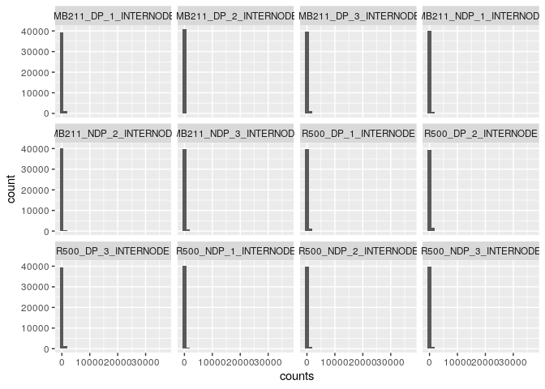

```r
pl <- counts.data.long %>%
  ggplot(aes(x = counts))+geom_histogram()+facet_wrap("Samples")
pl
```

**b.** Is the data normally distributed? Make a new set of histograms after applying an appropriate transformation if needed.

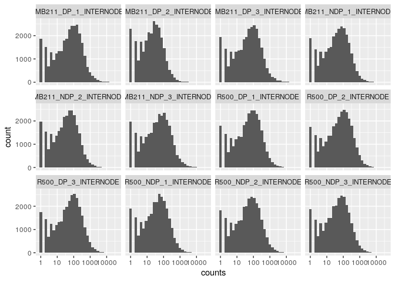

```r
pl2 <- counts.data.long %>%
  ggplot(aes(x = counts))+scale_x_log10()+geom_histogram()+facet_wrap("Samples")
pl2
```

```r
counts.data <- counts.data[rowSums(counts.data[,-1] > 10) >= 3,]
```

**Hint 1**: *You probably need to `gather` the data into long format. See the Rice SNP lab and spread and gather tutorial if you need a review*. **Hint 2**: *You can transform the axes in ggplot by adding* `scale_x_log10()` or `scale_x_sqrt()` *to the plot. One of these should be sufficient if you need to transform, but for other ideas see the [Cookbook for R page](http://www.cookbook-r.com/Graphs/Axes_%28ggplot2%29/#axis-transformations-log-sqrt-etc)*.

**Exercise 5:**  
We expect that read counts, especially from biological replicates, will be highly correlated. Check to see if this is the case using the `pairs()` function and the `cor()` function. Explain what each of these functions does and comment on the results.

**Important Hint:** *`pairs` is slow on the full dataset. Try it on the first 1,000 genes. Do you need to transform to make the pairs output more meaningful?*

**Important Hint2:** *it will be hard to see the pairs plot in the Rstudio inline display. Once you have the plot, click the expand to full window icon to display the plot in its own window. Alternatively, instead of using all columns of data, try it on a smaller number of columns*

**Hint 3:** *remember that you will need to remove the “gene_id” column before using the data in `pairs` or `cor`*

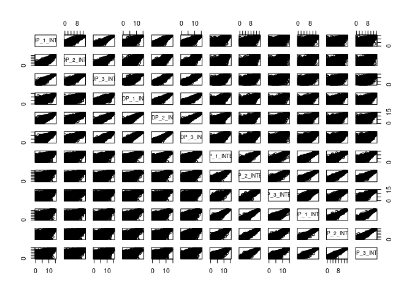

```r
counts.data[1-1000,-1] %>%
  magrittr::add(1)%>%log2()%>%
  pairs()
```

```r
counts.data[1-1000,-1] %>%
  magrittr::add(1)%>%log2()%>%
  cor()
```

```
##                        IMB211_DP_1_INTERNODE IMB211_DP_2_INTERNODE
## IMB211_DP_1_INTERNODE              1.0000000             0.9367019
## IMB211_DP_2_INTERNODE              0.9367019             1.0000000
## IMB211_DP_3_INTERNODE              0.9720846             0.9218534
## IMB211_NDP_1_INTERNODE             0.8931168             0.8480784
## IMB211_NDP_2_INTERNODE             0.9436243             0.9083546
## IMB211_NDP_3_INTERNODE             0.9267854             0.8931034
## R500_DP_1_INTERNODE                0.7232892             0.7478555
## R500_DP_2_INTERNODE                0.6836455             0.7126859
## R500_DP_3_INTERNODE                0.6838159             0.7024909
## R500_NDP_1_INTERNODE               0.6870518             0.7127469
## R500_NDP_2_INTERNODE               0.6565295             0.6811286
## R500_NDP_3_INTERNODE               0.6588589             0.6796944
##                        IMB211_DP_3_INTERNODE IMB211_NDP_1_INTERNODE
## IMB211_DP_1_INTERNODE              0.9720846              0.8931168
## IMB211_DP_2_INTERNODE              0.9218534              0.8480784
## IMB211_DP_3_INTERNODE              1.0000000              0.9046240
## IMB211_NDP_1_INTERNODE             0.9046240              1.0000000
## IMB211_NDP_2_INTERNODE             0.9405095              0.9470600
## IMB211_NDP_3_INTERNODE             0.9425114              0.9491658
## R500_DP_1_INTERNODE                0.7208710              0.7710693
## R500_DP_2_INTERNODE                0.6743830              0.7433788
## R500_DP_3_INTERNODE                0.6706201              0.7580467
## R500_NDP_1_INTERNODE               0.6834876              0.7644579
## R500_NDP_2_INTERNODE               0.6553236              0.7599015
## R500_NDP_3_INTERNODE               0.6558039              0.7536865
##                        IMB211_NDP_2_INTERNODE IMB211_NDP_3_INTERNODE
## IMB211_DP_1_INTERNODE               0.9436243              0.9267854
## IMB211_DP_2_INTERNODE               0.9083546              0.8931034
## IMB211_DP_3_INTERNODE               0.9405095              0.9425114
## IMB211_NDP_1_INTERNODE              0.9470600              0.9491658
## IMB211_NDP_2_INTERNODE              1.0000000              0.9555762
## IMB211_NDP_3_INTERNODE              0.9555762              1.0000000
## R500_DP_1_INTERNODE                 0.7809028              0.7662180
## R500_DP_2_INTERNODE                 0.7554044              0.7178257
## R500_DP_3_INTERNODE                 0.7583628              0.7182538
## R500_NDP_1_INTERNODE                0.7644610              0.7374205
## R500_NDP_2_INTERNODE                0.7444550              0.7180656
## R500_NDP_3_INTERNODE                0.7419544              0.7121965
##                        R500_DP_1_INTERNODE R500_DP_2_INTERNODE
```

[output cut: 23 more lines]

```
## R500_NDP_2_INTERNODE             0.9455463            0.9649933
## R500_NDP_3_INTERNODE             0.9423936            0.9701429
##                        R500_NDP_2_INTERNODE R500_NDP_3_INTERNODE
## IMB211_DP_1_INTERNODE             0.6565295            0.6588589
## IMB211_DP_2_INTERNODE             0.6811286            0.6796944
## IMB211_DP_3_INTERNODE             0.6553236            0.6558039
## IMB211_NDP_1_INTERNODE            0.7599015            0.7536865
## IMB211_NDP_2_INTERNODE            0.7444550            0.7419544
## IMB211_NDP_3_INTERNODE            0.7180656            0.7121965
## R500_DP_1_INTERNODE               0.9230799            0.9245820
## R500_DP_2_INTERNODE               0.9651563            0.9557632
## R500_DP_3_INTERNODE               0.9455463            0.9423936
## R500_NDP_1_INTERNODE              0.9649933            0.9701429
## R500_NDP_2_INTERNODE              1.0000000            0.9744688
## R500_NDP_3_INTERNODE              0.9744688            1.0000000
```

The pair function produces scatterplot for each variable combinations of the data frame. The plots in the corners variance grow very rapidly and scatters more. The cor function forms a variance-covariance matrix, using Pearson as method. The covariance decreases rapidly in the corner, corresponds to the pair function plot.

**Exercise 6:** Next use regular expressions, mutate, and the commands you learned in the stringr tutorial to create three new columns:

1. column “gt” that has either IMB211 or R500, indicating the genotype
2. column “trt” that indicates the treatment with either “NDP” or “DP”
3. column “grp” that has gt and trt pasted together with "_" as a separator. You can use `str_c()` and the “gt” and “trt” columns for this.

```r
sample.description <- tibble(sample=colnames(counts.data)[-1])
```

```r
title <- c("IMB211_DP_1_INTERNODE","IMB211_DP_2_INTERNODE","IMB211_DP3_INTERNODE","IMB211_NDP1_INTERNODE","IMB211_NDP_2_INTERNODE","IMB211_NDP_3_INTERNODE","R500_DP_1_INTERNODE","R500_DP_2_INTERNODE","R500_DP_3_INTERNODE","R500_NDP_1_INTERNODE","R500_NDP_2_INTERNODE","R500_NDP_3_INTERNODE")
sample.description <-sample.description %>%
  mutate(gt = title %>% str_extract("IMB211|R500"),trt = title %>% str_extract("NDP|DP"),group = str_c(gt,"_",trt))
sample.description
```

| sample | gt | trt | group |
| --- | --- | --- | --- |
| IMB211_DP_1_INTERNODE | IMB211 | DP | IMB211_DP |
| IMB211_DP_2_INTERNODE | IMB211 | DP | IMB211_DP |
| IMB211_DP_3_INTERNODE | IMB211 | DP | IMB211_DP |
| IMB211_NDP_1_INTERNODE | IMB211 | NDP | IMB211_NDP |
| IMB211_NDP_2_INTERNODE | IMB211 | NDP | IMB211_NDP |
| IMB211_NDP_3_INTERNODE | IMB211 | NDP | IMB211_NDP |
| R500_DP_1_INTERNODE | R500 | DP | R500_DP |
| R500_DP_2_INTERNODE | R500 | DP | R500_DP |
| R500_DP_3_INTERNODE | R500 | DP | R500_DP |
| R500_NDP_1_INTERNODE | R500 | NDP | R500_NDP |

[output cut: 2 more lines]

```r
sample.description <- sample.description %>%
  mutate(gt=factor(gt),
         trt=factor(trt,levels = c("NDP","DP"))) # setting the levels in this way makes "NDP" the reference

sample.description
```

| sample | gt | trt | group |
| --- | --- | --- | --- |
| IMB211_DP_1_INTERNODE | IMB211 | DP | IMB211_DP |
| IMB211_DP_2_INTERNODE | IMB211 | DP | IMB211_DP |
| IMB211_DP_3_INTERNODE | IMB211 | DP | IMB211_DP |
| IMB211_NDP_1_INTERNODE | IMB211 | NDP | IMB211_NDP |
| IMB211_NDP_2_INTERNODE | IMB211 | NDP | IMB211_NDP |
| IMB211_NDP_3_INTERNODE | IMB211 | NDP | IMB211_NDP |
| R500_DP_1_INTERNODE | R500 | DP | R500_DP |
| R500_DP_2_INTERNODE | R500 | DP | R500_DP |
| R500_DP_3_INTERNODE | R500 | DP | R500_DP |
| R500_NDP_1_INTERNODE | R500 | NDP | R500_NDP |

[output cut: 2 more lines]

```r
library(edgeR)
counts.matrix <- counts.data %>% select(-gene_id) %>% as.matrix()
rownames(counts.matrix) <- counts.data$gene_id

dge.data <- DGEList(counts=counts.matrix,
                    group=sample.description$group)
dim(dge.data)
```

```
## [1] 24034    12
```

```r
dge.data <- calcNormFactors(dge.data, method = "TMM")
dge.data$samples # look at the normalization factors
```

|  | group | lib.size | norm.factors |
| --- | --- | --- | --- |
| IMB211_DP_1_INTERNODE | IMB211_DP | 5490779 | 0.9599925 |
| IMB211_DP_2_INTERNODE | IMB211_DP | 1510063 | 1.0071912 |
| IMB211_DP_3_INTERNODE | IMB211_DP | 5201394 | 0.8859066 |
| IMB211_NDP_1_INTERNODE | IMB211_NDP | 3900431 | 0.9759586 |
| IMB211_NDP_2_INTERNODE | IMB211_NDP | 3079339 | 1.0014028 |
| IMB211_NDP_3_INTERNODE | IMB211_NDP | 4769616 | 0.9034489 |
| R500_DP_1_INTERNODE | R500_DP | 4824927 | 1.0426105 |
| R500_DP_2_INTERNODE | R500_DP | 5591866 | 1.0776337 |
| R500_DP_3_INTERNODE | R500_DP | 5130017 | 1.0144761 |
| R500_NDP_1_INTERNODE | R500_NDP | 3189641 | 1.0596401 |

[output cut: 2 more lines]

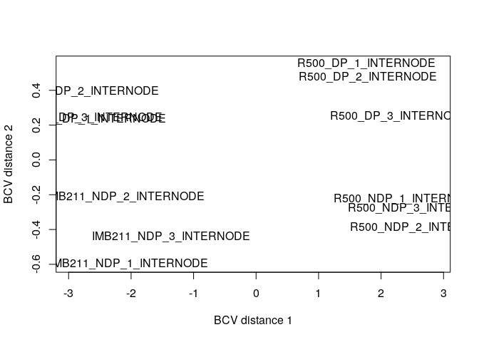

```r
plotMDS(dge.data, method = "bcv")
```

**Exercise 7**  
Discuss the MDS plot. Does it give you confidence in the experiment or cause concern?

As the plot shown, there are rather obvious 4 clusters and they match the grouping in the name, so I think the experiment should be fine.

**Exercise 8**  
To get a graphical idea for what the normalization does, make box plots of the count data for each sample before and after normalization. Discuss the effect of normalization.

```r
counts.data.normal <- cpm(dge.data)
```

**Hint 1**: _log2 transform the counts before plotting. Add a value of “1” before log2 transforming to avoid having to take the log2 of 0. Your transformation will look something like this:

```r
counts.data.log <- log2(counts.data[,-1] + 1)
counts.data.normallog <- log2(counts.data.normal + 1)
```

**Hint 2**: *If you don’t want to bother with gathering before going to ggplot, you can just use the `boxplot()` function and feed it the (transformed) matrix directly.*

**Hint 3**: Why do I use `[,-1]` above? Do you need to use this on `counts.data.normal`?

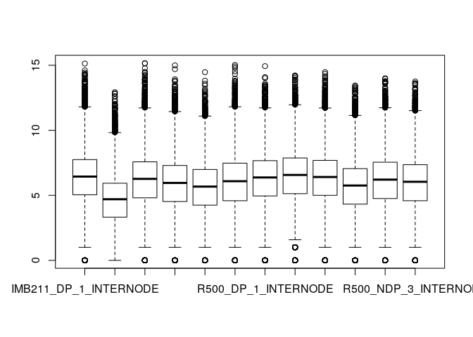

```r
boxplot(counts.data.log)
```

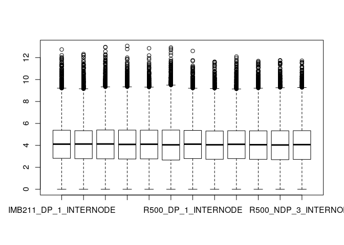

```r
boxplot(counts.data.normallog)
```

Normalization decreases the variances between samples, specifically, means are more similar and now the differences are valuable.

```r
design <- model.matrix(~gt+trt,data = sample.description)
rownames(design) <- sample.description$sample
design
```

```
##                        (Intercept) gtR500 trtDP
## IMB211_DP_1_INTERNODE            1      0     1
## IMB211_DP_2_INTERNODE            1      0     1
## IMB211_DP_3_INTERNODE            1      0     1
## IMB211_NDP_1_INTERNODE           1      0     0
## IMB211_NDP_2_INTERNODE           1      0     0
## IMB211_NDP_3_INTERNODE           1      0     0
## R500_DP_1_INTERNODE              1      1     1
## R500_DP_2_INTERNODE              1      1     1
## R500_DP_3_INTERNODE              1      1     1
## R500_NDP_1_INTERNODE             1      1     0
## R500_NDP_2_INTERNODE             1      1     0
## R500_NDP_3_INTERNODE             1      1     0
## attr(,"assign")
## [1] 0 1 2
## attr(,"contrasts")
## attr(,"contrasts")$gt
## [1] "contr.treatment"
##
## attr(,"contrasts")$trt
## [1] "contr.treatment"
```

```r
dge.data <- estimateGLMCommonDisp(dge.data,design,verbose = TRUE)
```

```
## Disp = 0.058 , BCV = 0.2408
```

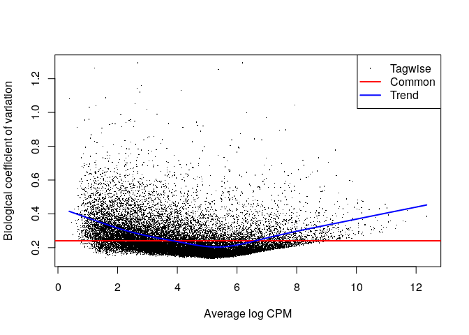

```r
#Then a trended dispersion based on count level
dge.data <- estimateGLMTrendedDisp(dge.data,design)

#And lastly we calculate the gene-wise dispersion, using the prior estimates to "squeeze" the dispersion towards the common dispersion.
dge.data <- estimateGLMTagwiseDisp(dge.data,design)

#We can examine this with a plot
plotBCV(dge.data)
```

```r
fit <- glmFit(dge.data, design)
gt.lrt <- glmLRT(fit,coef = "gtR500")
topTags(gt.lrt)
```

```
## Coefficient:  gtR500
##                logFC   logCPM       LR        PValue           FDR
## Bra033098 -12.153105 6.070823 998.8289 3.227155e-219 7.756145e-215
## Bra023495 -11.889171 5.792298 974.5077 6.243784e-214 7.503155e-210
## Bra016271 -14.250692 8.144467 891.3678 7.385316e-196 5.916623e-192
## Bra020631 -11.318315 5.206858 870.7722 2.216677e-191 1.331890e-187
## Bra011216 -11.258770 5.133650 853.8519 1.057186e-187 5.081683e-184
## Bra020643 -14.383988 8.280736 841.0553 6.399981e-185 2.563619e-181
## Bra009785   7.950946 6.018503 786.8301 3.939704e-173 1.352669e-169
## Bra011765  -7.319947 6.341553 749.4443 5.299422e-165 1.592079e-161
## Bra026924  -8.334013 5.028260 729.9894 9.005222e-161 2.404795e-157
## Bra029392   8.339064 6.296476 723.1411 2.777440e-159 6.675300e-156
```

```r
summary(decideTestsDGE(gt.lrt,p.value=0.01))
```

```
##        gtR500
## Down     5487
## NotSig  13562
## Up       4985
```

```r
DEgene.gt <- topTags(gt.lrt,n = Inf,p.value = 0.01)$table
```

```r
#save to a file
write.csv(DEgene.gt, "/home/ubuntu/LAB3/Assignment_6_Wang.Zun/output/DEgenes.gt.csv")
```

```r
plotDE <- function(genes, dge, sample.description) {
  require(ggplot2)
  require(reshape2)
  tmp.data <- t(log2(cpm(dge[genes,])+1))
  tmp.data <- merge(tmp.data,sample.description,by.x="row.names",by.y="sample")
  tmp.data <- melt(tmp.data,value.name="log2_cpm",variable.name="gene")
  pl <- ggplot(tmp.data,aes(x=gt,y=log2_cpm,fill=trt))
  pl <- pl + facet_wrap( ~ gene)
  pl <- pl + ylab("log2(cpm)") + xlab("genotype")
  pl <- pl + geom_boxplot()
  pl + theme(axis.text.x  = element_text(angle=45, vjust=1,hjust=1))
}
```

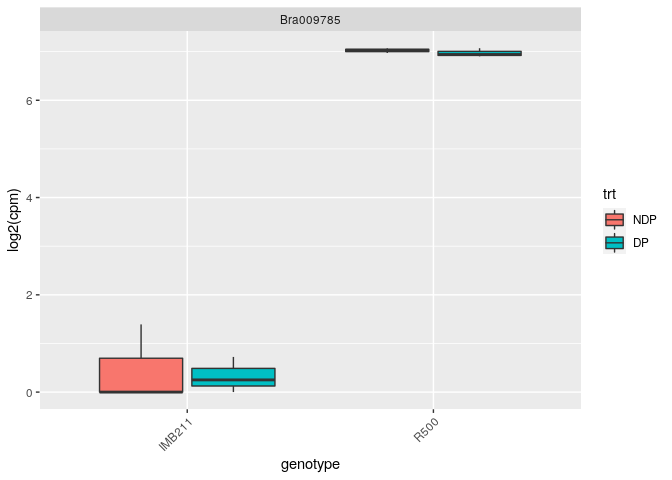

```r
plotDE("Bra009785",dge.data,sample.description)
```

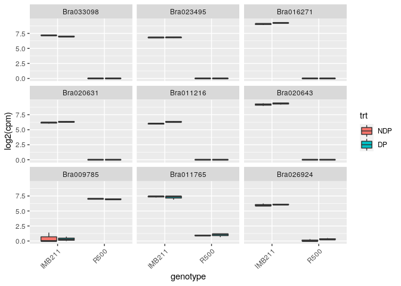

```r
#top 9 genes
plotDE(rownames(DEgene.gt)[1:9],dge.data,sample.description)
```

**Exercise 9**  
**a**. Find all genes differentially expressed in response to the DP treatment (at a FDR < 0.01).

```r
fit <- glmFit(dge.data, design)
gt.lrt <- glmLRT(fit,coef = "trtDP")
topTags(gt.lrt)
```

```
## Coefficient:  trtDP
##               logFC   logCPM        LR       PValue          FDR
## Bra028803 -5.043456 3.514222 132.19854 1.353794e-30 3.253710e-26
## Bra019324  4.809736 2.209125  76.43638 2.274232e-18 2.732944e-14
## Bra034565  4.081287 2.159299  68.93415 1.018066e-16 8.156062e-13
## Bra025587  4.190919 3.298713  55.04402 1.178607e-13 7.081657e-10
## Bra029946  2.280844 5.364465  47.80174 4.715738e-12 1.898675e-08
## Bra026156  1.764672 6.467797  47.50653 5.482101e-12 1.898675e-08
## Bra030161  2.846792 5.105622  47.48949 5.529967e-12 1.898675e-08
## Bra037739  2.041482 4.539958  47.09441 6.764836e-12 2.032326e-08
## Bra016050  5.119232 1.755334  46.01184 1.175405e-11 3.138853e-08
## Bra029042  3.496552 1.240656  45.59895 1.451195e-11 3.487801e-08
```

```r
summary(decideTestsDGE(gt.lrt,p.value=0.01))
```

```
##        trtDP
## Down     199
## NotSig 23415
## Up       420
```

**b**. How many genes are differentially expressed? 619.

**c**. Make a plot of the top 9

```r
DEgene.gt3 <- topTags(gt.lrt,n = Inf,p.value = 0.01)$table
```

```r
#save to a file
write.csv(DEgene.gt3, "/home/ubuntu/LAB3/Assignment_6_Wang.Zun/output/DEgenes.gt3.csv")
```

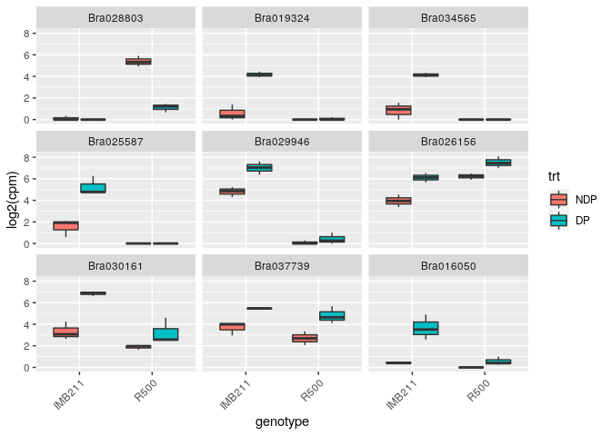

```r
plotDE(rownames(DEgene.gt3)[1:9],dge.data,sample.description)
```

**Exercise 10**: Gene by treatment interaction

```r
design.interaction <- model.matrix(~gt*trt,data = sample.description)
rownames(design.interaction) <- sample.description$sample
design.interaction
```

```
##                        (Intercept) gtR500 trtDP gtR500:trtDP
## IMB211_DP_1_INTERNODE            1      0     1            0
## IMB211_DP_2_INTERNODE            1      0     1            0
## IMB211_DP_3_INTERNODE            1      0     1            0
## IMB211_NDP_1_INTERNODE           1      0     0            0
## IMB211_NDP_2_INTERNODE           1      0     0            0
## IMB211_NDP_3_INTERNODE           1      0     0            0
## R500_DP_1_INTERNODE              1      1     1            1
## R500_DP_2_INTERNODE              1      1     1            1
## R500_DP_3_INTERNODE              1      1     1            1
## R500_NDP_1_INTERNODE             1      1     0            0
## R500_NDP_2_INTERNODE             1      1     0            0
## R500_NDP_3_INTERNODE             1      1     0            0
## attr(,"assign")
## [1] 0 1 2 3
## attr(,"contrasts")
## attr(,"contrasts")$gt
## [1] "contr.treatment"
##
## attr(,"contrasts")$trt
## [1] "contr.treatment"
```

**a**. Repeat the dispersion estimates and model fit but with the new model. Show code.

```r
dge.data2 <- dge.data
dge.data2 <- estimateGLMCommonDisp(dge.data2,design.interaction,verbose = TRUE)
```

```
## Disp = 0.05181 , BCV = 0.2276
```

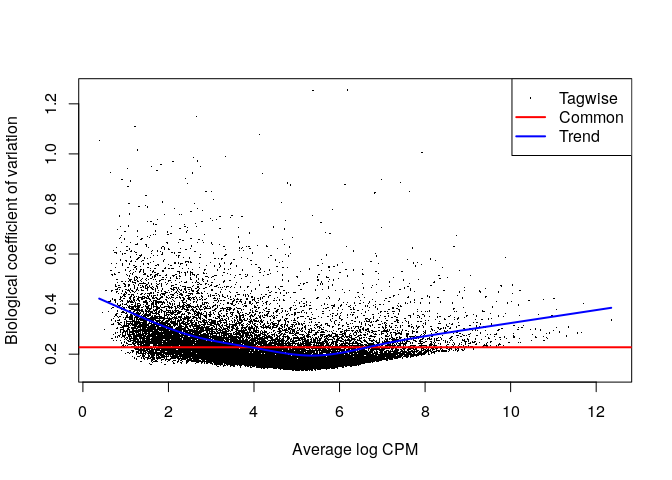

```r
#Then a trended dispersion based on count level
dge.data2 <- estimateGLMTrendedDisp(dge.data2,design.interaction)

#And lastly we calculate the gene-wise dispersion, using the prior estimates to "squeeze" the dispersion towards the common dispersion.
dge.data2 <- estimateGLMTagwiseDisp(dge.data2,design.interaction)

#We can examine this with a plot
plotBCV(dge.data2)
```

**b**. How many genes show a significantly different response to treatment in IMB211 as compared to R500? Save these genes to a file.

```r
fit2 <- glmFit(dge.data2, design.interaction)
gt.lrt2 <- glmLRT(fit2,coef = "gtR500:trtDP")
topTags(gt.lrt2)
```

```
## Coefficient:  gtR500:trtDP
##               logFC   logCPM        LR       PValue          FDR
## Bra010821  6.657166 6.040531 153.20040 3.463188e-35 8.323426e-31
## Bra033034 -4.639895 6.612226  71.22826 3.181984e-17 3.823790e-13
## Bra035334 -4.142507 4.667146  68.21558 1.465632e-16 1.174166e-12
## Bra003598 -4.893681 3.899939  54.11257 1.893265e-13 1.137568e-09
## Bra016182  7.714362 6.329657  49.61308 1.872611e-12 9.001269e-09
## Bra013164  4.098397 9.329035  48.02394 4.210458e-12 1.686569e-08
## Bra009406  6.199657 6.592917  47.38221 5.841049e-12 2.005483e-08
## Bra033856 -3.234819 5.717674  47.05381 6.906410e-12 2.074858e-08
## Bra011196  5.017764 3.352721  46.46026 9.349544e-12 2.496744e-08
## Bra041036 -3.280730 7.163369  45.79944 1.310012e-11 3.148482e-08
```

```r
summary(decideTestsDGE(gt.lrt2,p.value=0.01))
```

```
##        gtR500:trtDP
## Down            114
## NotSig        23784
## Up              136
```

```r
DEgene.gt2 <- topTags(gt.lrt2,n = Inf,p.value = 0.01)$table
```

```r
#save to a file
write.csv(DEgene.gt2, "/home/ubuntu/LAB3/Assignment_6_Wang.Zun/output/DEgenes.gt2.csv")
```

**c**. Make a plot of the top 9 genes that have a significantly different response to treatment in IMB211 as compared to R500.

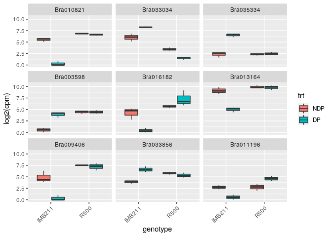

```r
plotDE(rownames(DEgene.gt2)[1:9],dge.data2,sample.description)
```